# Reproducible Research course - Assignment 1

Jakub Tomaszewski

Friday, July 18, 2014

This is my Assignment 1 report in the Reproducible Research course on Coursera.

Loading of the dataset into R workspace. Data source: https://d396qusza40orc.cloudfront.net/repdata%2Fdata%2Factivity.zip.

```r
library(data.table)
dataset <- read.csv("activity.csv")
```

Conversion of dataset to data.table type to increase the speed of processing:

```r
dataset <- data.table(dataset)
dataset$date <- as.POSIXct(dataset$date)
dataset$steps <- as.numeric(dataset$steps)
setkey(dataset,date)
sum_of_steps <- dataset[,list(steps=sum(steps)),by=list(date)]
print(head(sum_of_steps))
```

```
##          date steps
## 1: 2012-10-01    NA
## 2: 2012-10-02   126
## 3: 2012-10-03 11352
## 4: 2012-10-04 12116
## 5: 2012-10-05 13294
## 6: 2012-10-06 15420
```

Histogram of the total number of steps taken per day:

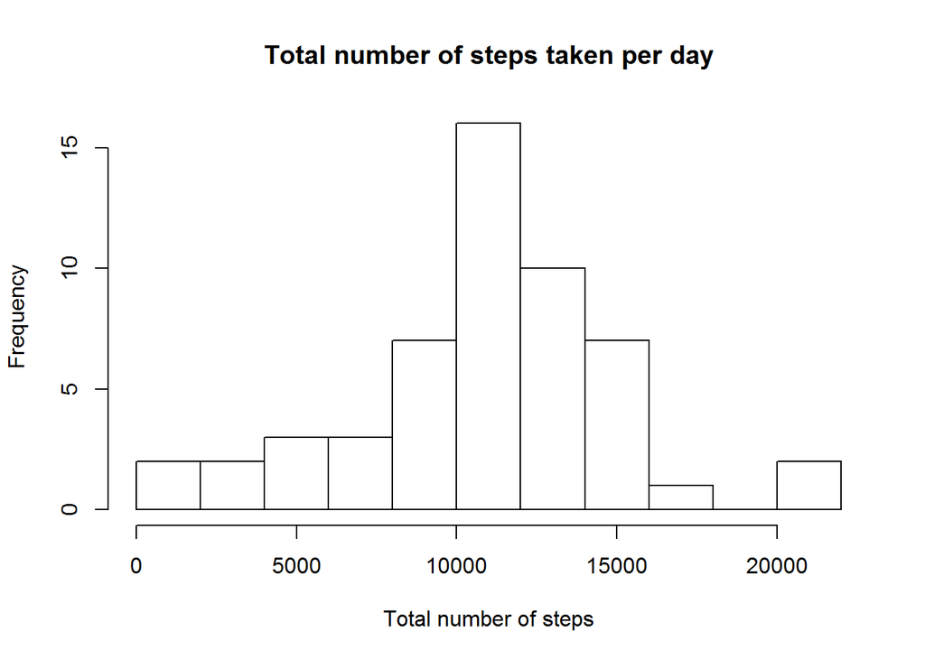

```r
hist(sum_of_steps$steps,main="Total number of steps taken per day",
     xlab="Total number of steps",breaks=10)
```

Mean and median total number of steps taken per day:

```r
mean_of_steps <- mean(sum_of_steps$steps,na.rm=TRUE)
print(mean_of_steps)
```

```
## [1] 10766
```

```r
median_of_steps <- median(sum_of_steps$steps,na.rm=TRUE)
print(median_of_steps)
```

```
## [1] 10765
```

Time series plot of the 5-minute interval (x-axis) and the average number of steps taken, averaged across all days:

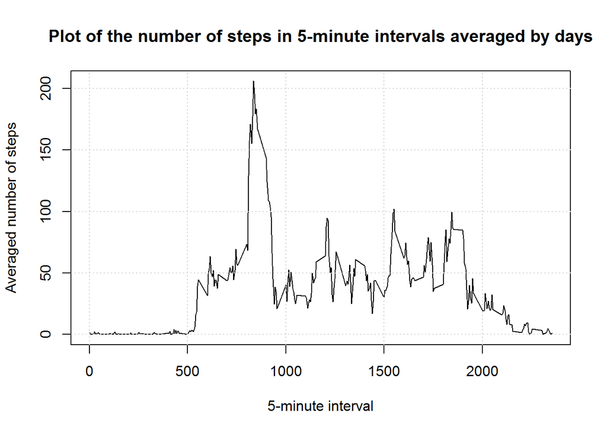

```r
means_of_steps_by_intervals <- dataset[,list(steps=mean(steps,na.rm=TRUE)),by=list(interval)]
plot(x=means_of_steps_by_intervals$interval,y=means_of_steps_by_intervals$steps,
     type="l",xlab="5-minute interval",ylab="Averaged number of steps",
     main="Plot of the number of steps in 5-minute intervals averaged by days")
grid()
```

Which 5-minute interval, on average across all the days in the dataset, contains the maximum number of steps?

```r
maximum_number_of_steps <- means_of_steps_by_intervals[which.max(steps)]
print(maximum_number_of_steps)
```

```
##    interval steps
## 1:      835 206.2
```

Imputation of missing values

Number of missing values:

```r
number_of_missing <- sum(is.na(dataset$steps))
print(number_of_missing)
```

```
## [1] 2304
```

```r
dataset_imputed <- dataset # Creating a local copy of dataset for imputation
intervals <- unique(dataset$interval) # Vector of unique dates in the dataset
for(i in 1:length(intervals)){
    tmp <- dataset_imputed[interval==intervals[i]]$steps
    dataset_imputed[interval==intervals[i]]$steps <- replace(tmp,is.na(tmp),mean(tmp,na.rm=TRUE))
}
```

Histogram of the total number of steps taken per day (after imputation)

Comparison with distribution of total number of steps in non-imputed dataset:

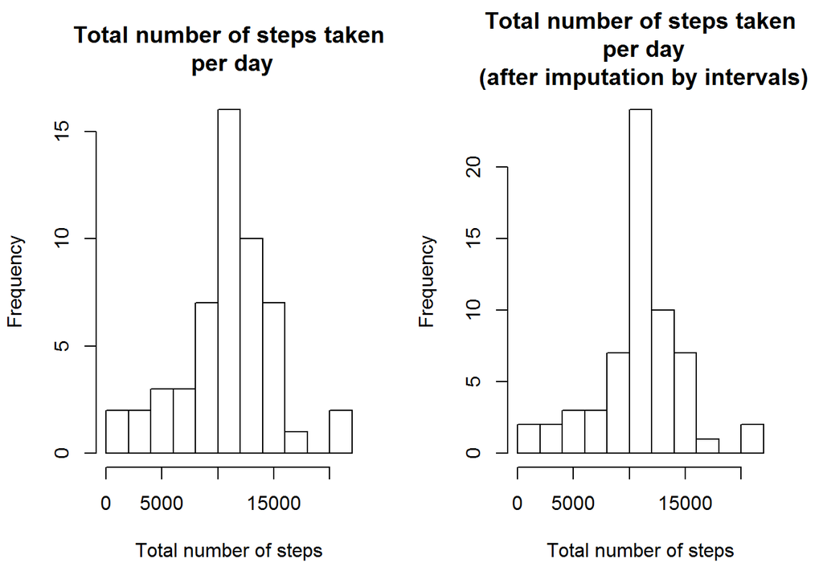

```r
sum_of_steps_imputed <- dataset_imputed[,list(steps=sum(steps)),by=list(date)]
par(mfrow=c(1,2))
hist(sum_of_steps$steps,main="Total number of steps taken\n per day",
     xlab="Total number of steps",breaks=10)
hist(sum_of_steps_imputed$steps,main="Total number of steps taken\n per day\n (after imputation by intervals)",
     xlab="Total number of steps",breaks=10)
```

Mean and median total number of steps taken per day (after imputation):

```r
mean_of_steps_imputed <- mean(sum_of_steps_imputed$steps,na.rm=TRUE)
print(mean_of_steps_imputed)
```

```
## [1] 10766
```

```r
median_of_steps_imputed <- median(sum_of_steps_imputed$steps,na.rm=TRUE)
print(median_of_steps_imputed)
```

```
## [1] 10766
```

Weekdays factor variable creation:

```r
weekday <- c("Sunday", "Monday", "Tuesday", "Wednesday", "Thursday",
            "Friday", "Saturday")[as.POSIXlt(dataset_imputed$date)$wday + 1]
dataset_imputed$weektime <- ifelse(weekday %in% c("Saturday","Sunday"),"weekend","weekday")
head(dataset_imputed)
```

```
##      steps       date interval weektime
## 1: 1.71698 2012-10-01        0  weekday
## 2: 0.33962 2012-10-01        5  weekday
## 3: 0.13208 2012-10-01       10  weekday
## 4: 0.15094 2012-10-01       15  weekday
## 5: 0.07547 2012-10-01       20  weekday
## 6: 2.09434 2012-10-01       25  weekday
```

Mean and median total number of steps taken per day (after imputation) by weekday/weekend:

```r
sum_of_steps_imputed_by_weektime <- dataset_imputed[,list(steps=sum(steps)),by=list(weektime,date)]
means_of_steps_imputed_by_weektime <- sum_of_steps_imputed_by_weektime[,list(steps=mean(steps)),by=list(weektime)]
print(means_of_steps_imputed_by_weektime)
```

```
##    weektime steps
## 1:  weekday 10256
## 2:  weekend 12202
```

```r
medians_of_steps_imputed_by_weektime <- sum_of_steps_imputed_by_weektime[,list(steps=median(steps)),by=list(weektime)]
print(medians_of_steps_imputed_by_weektime)
```

```
##    weektime steps
## 1:  weekday 10765
## 2:  weekend 11646
```

Time series plot of the 5-minute interval (x-axis) and the average number of steps taken, averaged across all days (for imputed data):

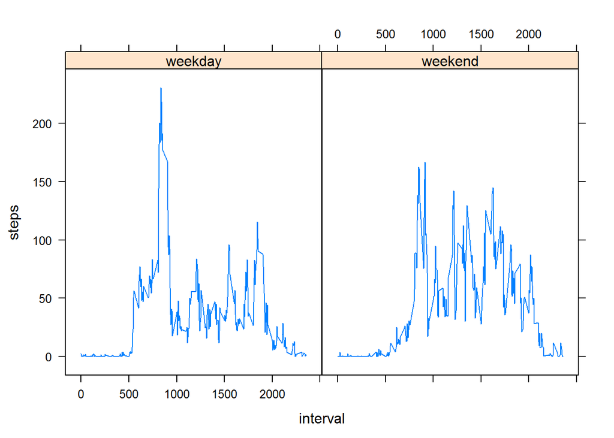

```r
means_of_steps_by_intervals_imputed <- dataset_imputed[,list(steps=mean(steps,na.rm=TRUE)),by=list(weektime,interval)]
library(lattice)
xyplot(steps~interval|weektime,data=means_of_steps_by_intervals_imputed, type="l")
```